# Dimensionality Reduction

```r
library(tidyverse)
library(ggfortify)
library(FactoMineR) # PCA and CA
library(ca) # CA
library(vcd)
theme_set(theme_bw())

#Sys.setlocale(locale = "ru_RU.UTF-8")
```

## Principal component analysis (PCA)

### 1. Main approaches to the dimensionality reduction

Sometimes you have a huge amount of variables. To make your data profitable and more clearly structured, you may want to reduce the number of variables – not loosing too much information.

- Principal component analysis (PCA)
- Linear discriminant analysis (LDA)
- Multidimensional scaling (MDS)
- …
- t-SNE For categorical variables:
- Correspondense analysis (CA)
- Multiple correspondence analysis (MCA)

### 2. Mother an Child data set

This is a dataset from [Huttenlocher, Vasilyeva, Cymerman, Levine 2002]. The authors analysed 46 pairs of mothers and children (aged from 47 to 59 months, mean age – 54). They recorded and transcribed 2 hours from each child per day. In their study, they compared the number of noun phrases per utterance in mother speech to the number of noun phrases per utterance in child speech.

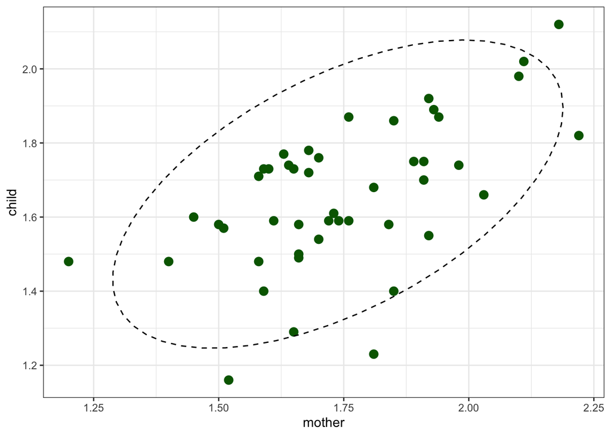

```r
df <- read_csv("https://raw.githubusercontent.com/LingData2019/LingData2020/master/data/Huttenlocher.csv")

df %>%
  ggplot(aes(mother, child))+
  geom_point(color = "darkgreen", size = 3)+
  stat_ellipse(linetype=2)+
  theme_bw()
```

### 3. PCA

PCA is essentially a rotation of the coordinate axes, chosen such that each successful axis captures as much variance as possible.

#### Recap: PCA is alternative to regression

One can reduce 2 dimensions to one using a regression:

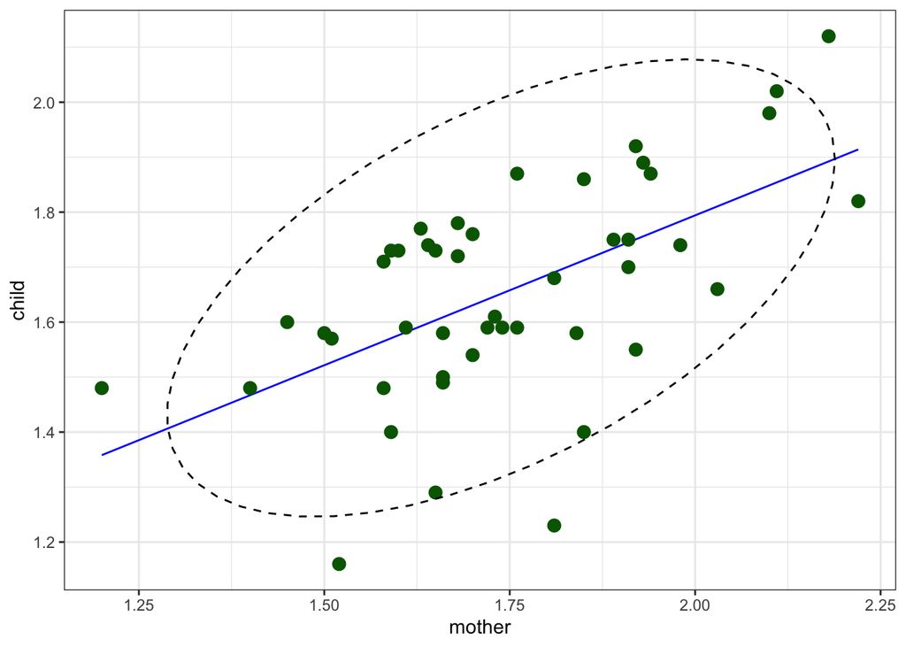

```r
fit <- lm(child~mother, data = df)
df$model <- predict(fit)

p1 <- df %>%
  ggplot(aes(mother, child)) +
  geom_line(aes(mother, model), color = "blue") +
  geom_point(color = "darkgreen", size = 3) +
  stat_ellipse(linetype=2) +
  scale_y_continuous(breaks = c(1.2, 1.4, 1.6, 1.8, 2.0)) +
  theme_bw()
p1
```

We used regression for predicting value of one variable by another variable.

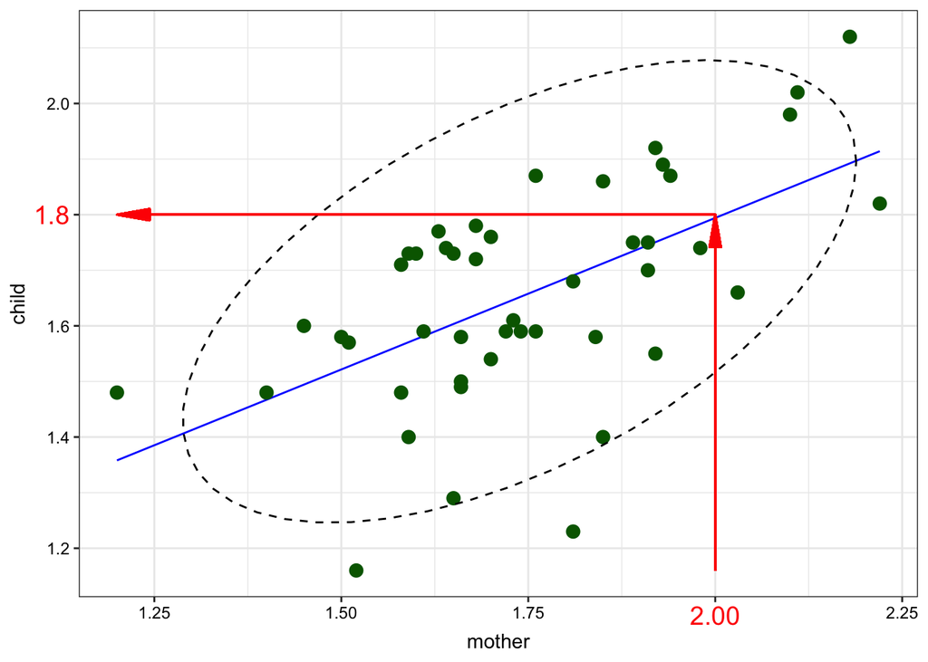

```r
p1 +
# plot red arrows
  geom_segment(aes(x=min(mother), y=1.8, xend=2, yend=1.8), size=0.5, color = "red",
               arrow =  arrow(angle = 10, type = "closed", ends = "first")) +
  geom_segment(aes(x=2, y=min(child), xend=2, yend=1.8), size=0.5, color = "red",
               arrow =  arrow(angle = 10, type = "closed")) +
# pin two points on axes
  theme(axis.text.x = element_text(color=c("black", "black", "black", "red", "black"), size=c(9, 9, 9, 14, 9)),
      axis.text.y = element_text(color=c("black", "black", "black", "red", "black", "black"), size=c(9, 9, 9, 14, 9, 9)))
```

In PCA we change coordinate system and start predicting variables’ values using less variables.

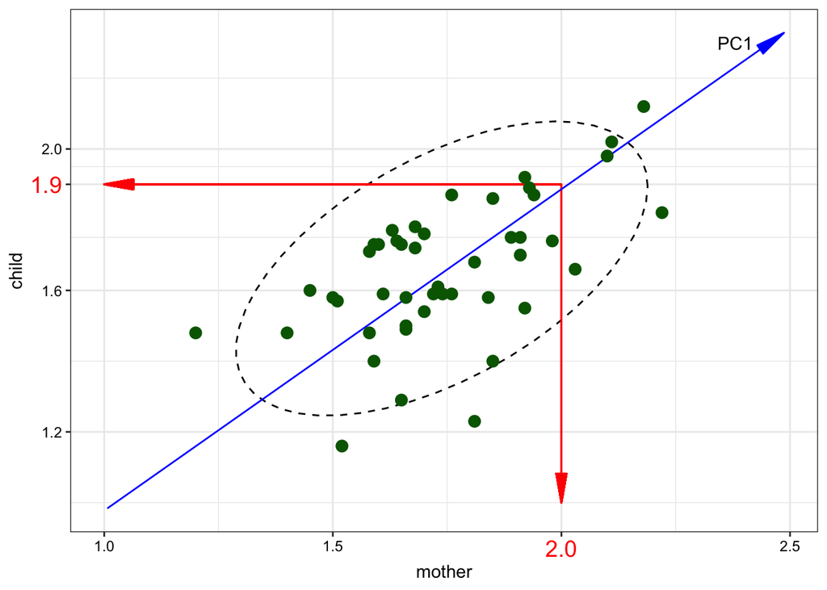

The blue line is *the first Princple Component* (and it is NOT a regression line). The number of the PCs is always equal to the number of variables. So we can draw the second PC:

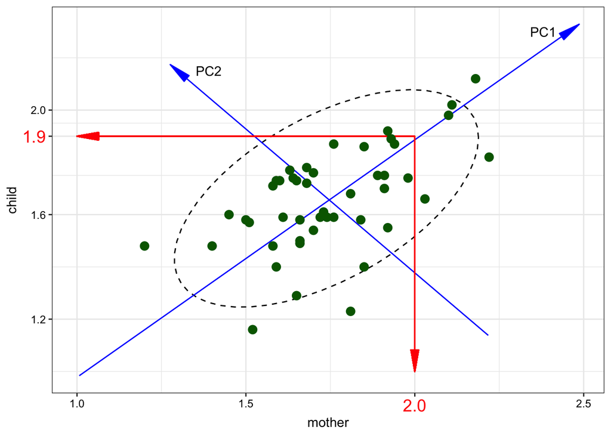

The main point of PCA is that if cumulative proportion of explained variance is high we can drop some PCs. So, we need know the following things:

- What is the cumulative proportion of explained variance?

```r
df <- read_csv("https://raw.githubusercontent.com/LingData2019/LingData2020/master/data/Huttenlocher.csv")
summary(prcomp(df))
```

```
## Importance of components:
##                           PC1    PC2
## Standard deviation     0.2544 0.1316
## Proportion of Variance 0.7890 0.2110
## Cumulative Proportion  0.7890 1.0000
```

We see that PC1 explains only 78.9% of the variance in our data.

- How PCs are rotated comparing to the old axes?

```r
prcomp(df)
```

```
## Standard deviations (1, .., p=2):
## [1] 0.2543899 0.1315688
##
## Rotation (n x k) = (2 x 2):
##              PC1        PC2
## child  0.6724959 -0.7401009
## mother 0.7401009  0.6724959
```

So the formula for the first component rotation is
$$PC1 = 0.6724959 \times child + 0.7401009 \times
mother$$
The formula for the second component rotation is
$$PC2 = -0.7401009 \times child + 0.6724959 \times
mother$$
Now we can change the axes. We use the `autoplot()` function from `ggfortify` package to produce the graph:

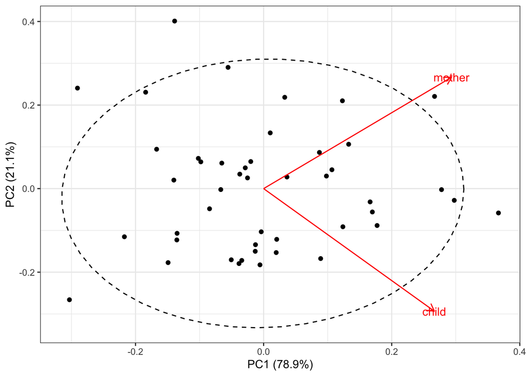

```r
autoplot(pca,
         loadings = TRUE,
         loadings.label = TRUE) +
  theme_bw() +
  stat_ellipse(linetype=2)
```

### Summary:

- If the cumulative proportion of explained variance for some PCs is high, we can change coordinate system and start predicting variables’ values using less variables.
- We can even make a regresion or clusterisation model.
- PCA for categorical variables is called Multiple correspondence analysis (MCA)

### R functions

There are several functions for PCA, MCA and their visualisation.

- PCA: prcomp()
- PCA: princomp()
- PCA: FactoMineR::PCA()
- PCA: ade4::dudi.pca()
- PCA: amap::acp()
- PCA visualisation: ggfortify::autoplot

### 2 Gospels’ frequency word lists

The gospels of Matthew, Mark, and Luke are referred to as the Synoptic Gospels and stand in contrast to John, whose content is comparatively distinct. This dataset (https://tinyurl.com/y8tcf3uw) contains frequency of selected words (without stopwords, without pronouns and without frequent word “Jesus”) as attested in four gospels of the New Testament.

For some visualisations you will need assign row names to the dataframe:

```r
gospels <- read.csv("https://tinyurl.com/y8tcf3uw", stringsAsFactors = T)
row.names(gospels) <- gospels$word
```

#### 2.2 Apply PCA to four continuous variables. Use `prcomp()` function. What is the cumulative proportion of explained variance for the first and second component?

```r
PCA <- prcomp(gospels[,2:5], center = TRUE, scale. = TRUE)
summary(PCA)
```

```
## Importance of components:
##                           PC1    PC2     PC3     PC4
## Standard deviation     1.7556 0.6903 0.50983 0.42619
## Proportion of Variance 0.7705 0.1191 0.06498 0.04541
## Cumulative Proportion  0.7705 0.8896 0.95459 1.00000
```

#### 2.2 Use the `autoplot()` function of the library ggfortify for creating plot like this.

See more examples here: https://cran.r-project.org/web/packages/ggfortify/vignettes/plot_pca.html

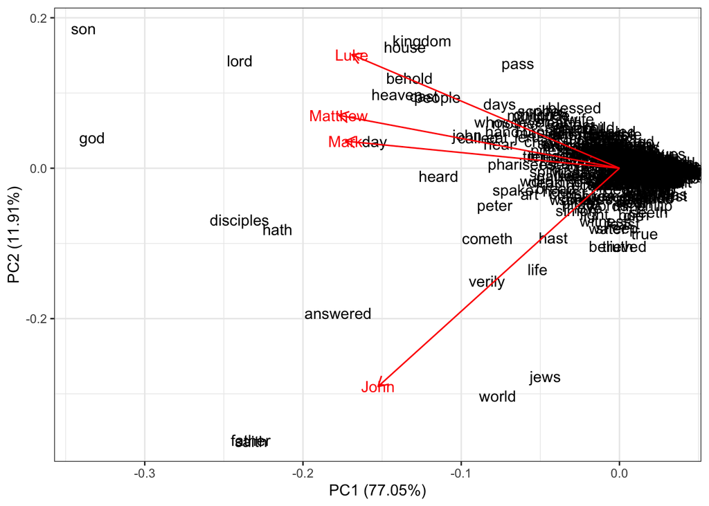

```r
autoplot(PCA,
         shape = FALSE,
         loadings = TRUE,
         label = TRUE,
         loadings.label = TRUE)+
  theme_bw()
```

#### 2.3 Predict the coordinates for the word “Jesus”, which have the following frequencies: John = 0.05, Luke = 0.01, Mark = 0.02, Matthew = 0.02.

```r
predict(PCA, data.frame(John = 0.05, Luke = 0.01, Mark = 0.02, Matthew = 0.02))
```

```
##            PC1       PC2      PC3      PC4
## [1,] -22.60497 -9.599171 2.367918 2.104944
```

We can also look at PC2 and PC3 components:

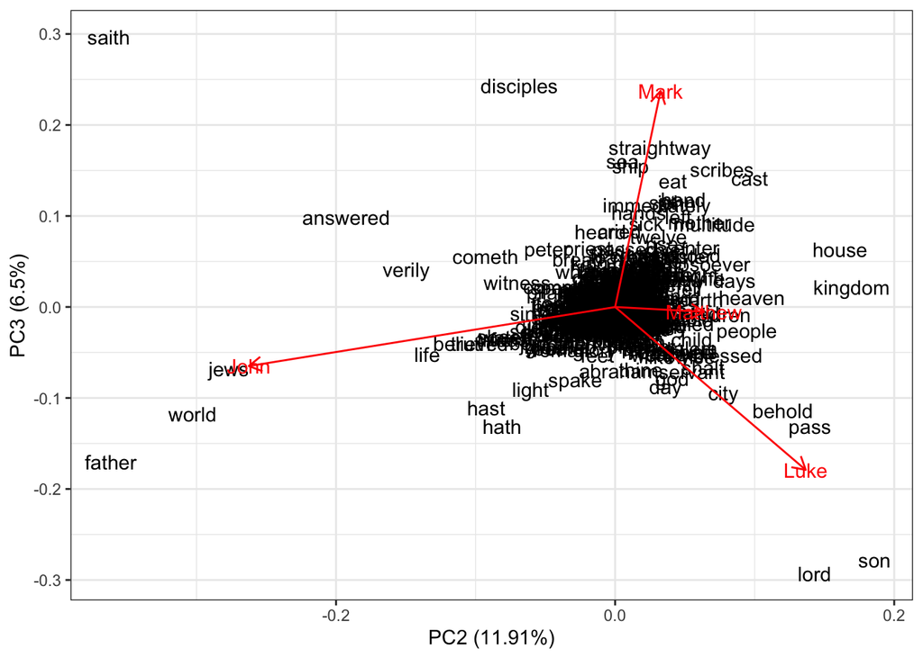

```r
autoplot(PCA, x=2, y=3,
         shape = FALSE,
         loadings = TRUE,
         label = TRUE,
         loadings.label = TRUE)+
  theme_bw()
```

#### Excercise: Register variation in the British National Corpus

Dataset and discription from Natalia Levshina’s package Rling. This is a data set with relative frequencies (proportions) of different word classes in 69 subcorpora of the British National Corpus (the BYU-BNC version).

- `Reg` — a factor that describes the metaregister with levels Acad, Fiction, Misc, News, NonacProse and Spok
- `Ncomm` — a numeric vector with relative frequencies of common nouns.
- `Nprop` — a numeric vector with relative frequencies of proper nouns.
- `Vpres` — a numeric vector with relative frequencies of verbs in the present tense form, 3rd person singular.
- `Vpast` — a numeric vector with relative frequencies of verbs in the past tense form.
- `P1` — a numeric vector with relative frequencies of the first-person pronouns.
- `P2` — a numeric vector with relative frequencies of the second-person pronouns.
- `Adj` — a numeric vector with relative frequencies of adjectives.
- `ConjCoord` — a numeric vector with relative frequencies of coordinating conjunctions.
- `ConjSub` — a numeric vectorwith relative frequencies of subordinating conjunctions.
- `Interject` — a numeric vector with relative frequencies of interjections.
- `Num` — a numeric vector with relative frequencies of numerals.

Q1 Apply PCA to all variables. What is the cumulative proportion of explained variance for the first, second and third components? Q2 Extract the coordinates from the pca object (pca$x), merge with the dataset itself, and create a visualization using the first two components and creating confidence ellipses for each metaregister.

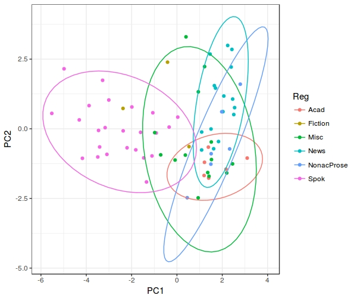

```r
reg_bnc <- read.csv("https://goo.gl/19QywL")
pca <- prcomp(reg_bnc[,-1], center = TRUE, scale. = TRUE)
summary(pca)
```

```
## Importance of components:
##                           PC1    PC2    PC3     PC4     PC5     PC6    PC7
## Standard deviation     2.2513 1.3683 1.1730 0.88886 0.80320 0.64940 0.5480
## Proportion of Variance 0.4607 0.1702 0.1251 0.07183 0.05865 0.03834 0.0273
## Cumulative Proportion  0.4607 0.6310 0.7560 0.82786 0.88650 0.92484 0.9521
##                            PC8     PC9    PC10    PC11
## Standard deviation     0.43204 0.37908 0.32981 0.29551
## Proportion of Variance 0.01697 0.01306 0.00989 0.00794
## Cumulative Proportion  0.96911 0.98217 0.99206 1.00000
```

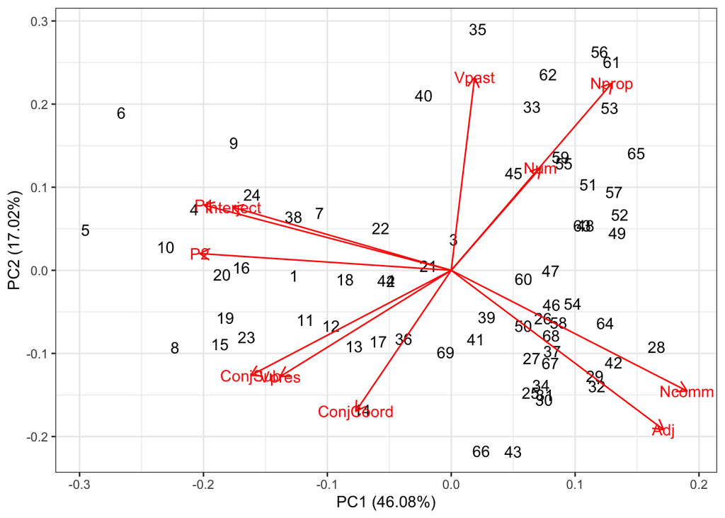

```r
autoplot(pca,
         shape = FALSE,
         loadings = TRUE,
         label = TRUE,
         loadings.label = TRUE)+
  theme_bw()
```

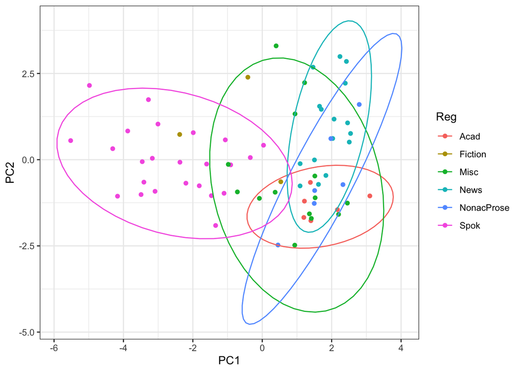

```r
#?prcomp
reg_bnc <- cbind(reg_bnc, pca$x)
reg_bnc %>%
  ggplot(aes(PC1, PC2, color = Reg))+
  geom_point()+
  stat_ellipse()+
  theme_bw()
```

## 3. Grammatical profiles of Russian verbs dataset

In their article “Predicting Russian aspect by frequency across genres” Eckhoff et al. (2017) ask whether the aspect of individual verbs can be predicted based on the statistical distribution of their inflectional forms. The dataset contains a sample of sentences taken from the Russian National Corpus. Each verb was annotated by Mood&Tense, Voice, Aspect and other grammatical features.

```r
ru <- read.csv('https://raw.githubusercontent.com/agricolamz/2018-MAG_R_course/master/data/RNCverbSamples_journ.csv', sep=';')
str(ru)
```

```
## 'data.frame':    52716 obs. of  14 variables:
##  $ FormTranslit : chr  "otkryl" "podnjat" "zazhzhjon" "privetstvovali" ...
##  $ LemmaTranslit: chr  "otkryt'" "podnjat'" "zazhech'" "privetstvovat'" ...
##  $ MoodTense    : chr  "indicpast" "indicpast" "indicpast" "indicpast" ...
##  $ Trans        : chr  "tran" "tran" "tran" "tran" ...
##  $ Voice        : chr  "act" "pass" "pass" "act" ...
##  $ VoicePartcp  : chr  "" "pass" "pass" "" ...
##  $ Person       : chr  "" "" "" "" ...
##  $ Number       : chr  "sg" "sg" "sg" "pl" ...
##  $ Gender       : chr  "m" "m" "m" "" ...
##  $ Long         : chr  "" "short" "short" "" ...
##  $ AspPair      : logi  NA NA NA NA NA NA ...
##  $ Aspect       : chr  "p" "p" "p" "i" ...
##  $ Mood         : chr  "indic" "indic" "indic" "indic" ...
##  $ Tense        : chr  "past" "past" "past" "past" ...
```

First, we will do some preprocessing. Here, we join future passives with other passive participles.

```r
ru$MoodTense[ru$Voice == 'pass' & ru$MoodTense == 'indicfut'] <- "partcppast"
```

Let’s look at top-10 of verbs in the dataset

```r
ru %>%
  group_by(LemmaTranslit) %>%
  summarize(count=n()) %>%
  arrange(desc(count))
```

| LemmaTranslit | count |
| --- | --- |
| byt' | 2763 |
| moch' | 1125 |
| stat' | 820 |
| govorit' | 525 |
| skazat' | 432 |
| znat' | 334 |
| imet' | 328 |
| sdelat' | 320 |
| poluchit' | 316 |
| schitat' | 305 |

[output cut: 5930 more lines]

### 3.1 Grammatical profiles

Grammatical profile is a vector that contains the number (or the ratio) of inflectional forms for individual lemmas. We can pick up a subset containing only forms of the verb *chitat’* ‘read’.

```r
ru.chit <- droplevels(subset(ru, LemmaTranslit == "chitat'"))
```

This is the grammatical profile of *chitat’*

```r
print("The grammatical profile of chitat'")
```

```
## [1] "The grammatical profile of chitat'"
```

```r
print(table(ru.chit$MoodTense))
```

```
##
##   gernonpast        imper     indicfut indicnonpast    indicpast          inf
##            2            8            1           15           14           22
```

```r
print(prop.table(table(ru.chit$MoodTense))*100)
```

```
##
##   gernonpast        imper     indicfut indicnonpast    indicpast          inf
##     3.225806    12.903226     1.612903    24.193548    22.580645    35.483871
```

Now we will calculate the grammatical profile of each verb (which has more than 50 occurrences in our data set) and split the resulting table into two parts: grammatical forms themselves (numeric data, see ttdata below) and metadata (categories labeled in the RNC or by annotators: lemma, trasitivity, aspect).

Table of tense-mood distribution per lemma:

```r
tab = table(ru$LemmaTranslit,ru$MoodTense)
#turns the table into a data frame
t = as.data.frame.matrix(tab)
#adds lemmas as a separate column
t$LemmaTranslit <- row.names(t)
#adds metadata columns for transitivity and aspect, assuming that these are stable per lemma - just picking the first value per lemma
t$Trans = as.factor(unlist(lapply(t$LemmaTranslit, function(x) names(table(subset(ru, LemmaTranslit == x)$Trans)))[1]))
t$Asp = as.factor(unlist(lapply(t$LemmaTranslit, function(x) names(table(subset(ru, LemmaTranslit == x)$Aspect)))[1]))
```

Label the biaspectuals ‘b’:

```r
levels(t$Asp) <- c('i','p','b')
t[t$LemmaTranslit=="ispol'zovat'",]$Asp <- 'b'
t[t$LemmaTranslit=="obeschat'",]$Asp <- 'b'
```

Pick out the lemmas with 50 or more occurrences and split the data:

```r
tt <- t[rowSums(t[,1:9]) >= 50,]
```

## 4. t-SNE visualization (for numeric variables)

The idea behind this kind of visualisation is to plot different clusters as far from each other as possible (preserving the distance between each pair of clusters). Within each cluster, the points are distributed to show the internal structure of the cluster. Note that unlike PCA, in t-SNE the points’ coordinates cannot be interpreted directly (there is no linear mapping of one plane to another), and linear correlations can be misleading.

```r
library(Rtsne)
ru.tsne <- Rtsne(tt[,1:9],
                 dims=2,
                 perplexity=50,
                 verbose=TRUE,
                 max_iter = 2000)
```

[output not shown]

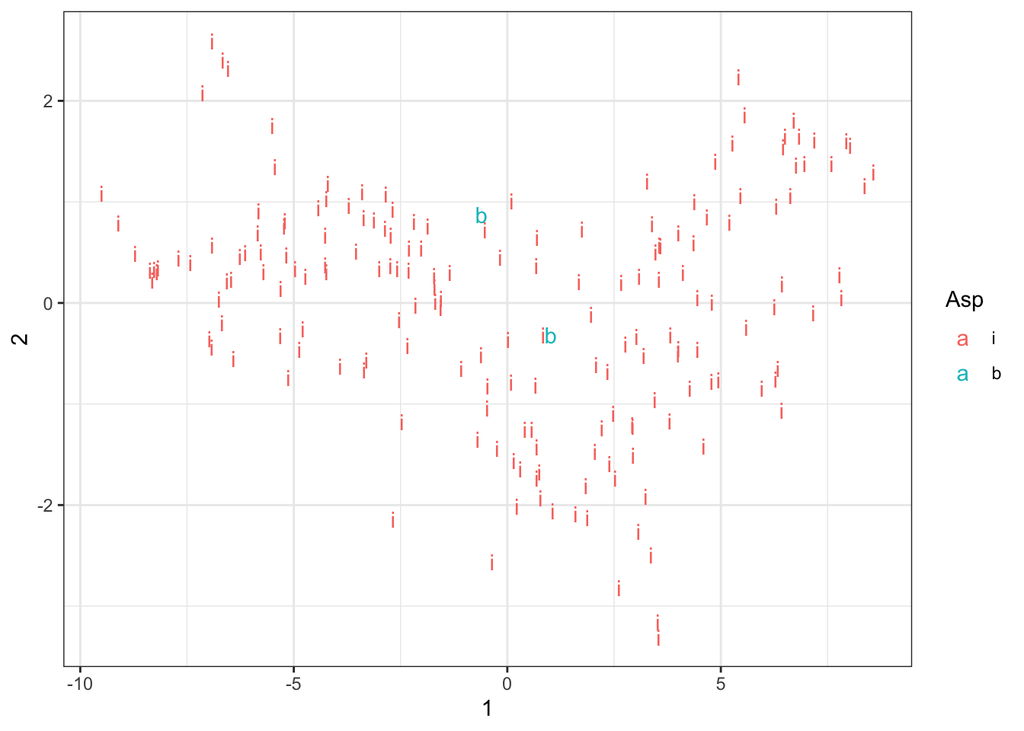

```r
tt <- cbind(tt, ru.tsne$Y)

tt %>%
  ggplot(aes(`1`, `2`, label = Asp, color = Asp))+
  geom_text()
```

## 5. Correspondence Analysis

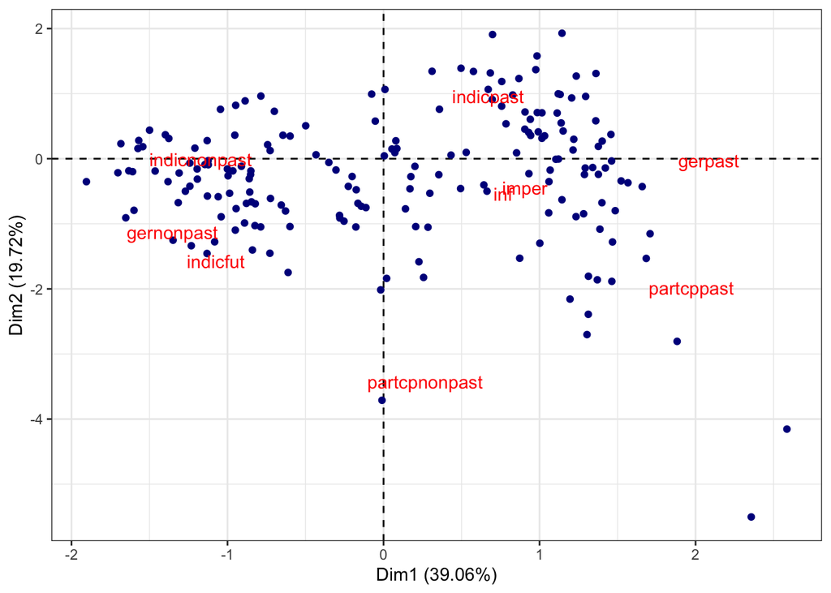

```r
tt_ca <- ca(tt[,1:9])

tt_col <- data.frame(tt_ca$colcoord)
tt_col$rows <- rownames(tt_ca$colcoord)

tt_row <- data.frame(tt_ca$rowcoord)
tt_row$rows <- rownames(tt_ca$rowcoord)

tt_col %>%
  ggplot(aes(Dim1, Dim2))+
  geom_hline(yintercept = 0, linetype = 2)+
  geom_vline(xintercept = 0,linetype = 2)+
  geom_point(data = tt_row, aes(Dim1, Dim2), color = "darkblue")+
  geom_text(aes(label = rows), color = "red")+
  labs(x = "Dim1 (39.06%)",
       y = "Dim2 (19.72%)")
```

## 6. Multiple correspondence analysis

- Aux — a factor that specifies the causative auxiliary with levels laten and doen.
- Country — a factor with levels NL (the Netherlands) and BE (Belgium).
- Causation — a factor that describes the type of causation with levels Affective, Inducive, Physical and Volitional
- EPTrans — a factor that specifies the transitivity of the Effected Predicate with levels Intr (intransitive) and Tr (transitive).
- EPTrans1 — a factor with levels Intr and Tr. It is very similar to the previous one, except for a few observations.

```r
dutch_caus <- read.csv("https://goo.gl/2yAR3T", stringsAsFactors = T)
MCA <- MASS::mca(dutch_caus[,-1])
MCA
```

```
## Call:
## MASS::mca(df = dutch_caus[, -1])
##
## Multiple correspondence analysis of 500 cases of 7 factors
##
## Correlations 0.577 0.458  cumulative % explained  9.62 17.25
```

```r
dutch_caus <- cbind(dutch_caus, MCA$rs)
variables <- as_data_frame(MCA$cs)
```

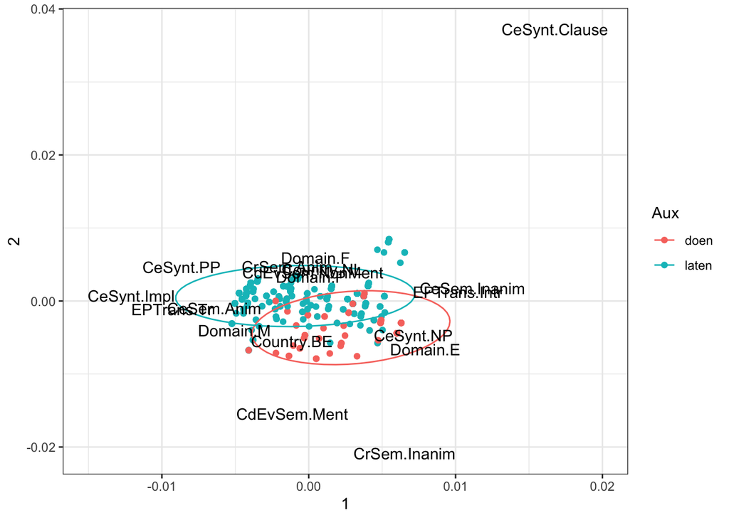

```r
variables$var_names <- rownames(MCA$cs)
dutch_caus %>%
  ggplot(aes(`1`, `2`))+
  geom_point(aes(color = Aux))+
  stat_ellipse(aes(color = Aux))+
  geom_text(data = variables, aes(`1`, `2`, label = var_names))+
  theme_bw()+
  scale_x_continuous(limits = c(-0.015, 0.02))
```

### Useful links

- FactoMineR for PCA [link](http://www.sthda.com/english/articles/31-principal-component-methods-in-r-practical-guide/112-pca-principal-component-analysis-essentials/)